# Final Project

### UID: 604995902

### Worked with: Tanvi Pati (UID: 104901736)

```r
library(dplyr)
library(knitr)
library(stringr)
library(ggplot2)
```

Loading the data frame:

```r
amazon <- load("AmazonFinal7.RData")
```

```r
summary(Amazon7A)
```

```
##   customer_id        review_id         helpful_votes
##  Min.   :   10192   Length:451411      Min.   :   0.000
##  1st Qu.:15036873   Class :character   1st Qu.:   0.000
##  Median :27855034   Mode  :character   Median :   0.000
##  Mean   :28771234                      Mean   :   1.643
##  3rd Qu.:43173204                      3rd Qu.:   1.000
##  Max.   :53096436                      Max.   :2628.000
##  review_body            vine           review_headline
##  Length:451411      Length:451411      Length:451411
##  Class :character   Class :character   Class :character
##  Mode  :character   Mode  :character   Mode  :character
##
##
##
##  product_title
##  Length:451411
##  Class :character
##  Mode  :character
##
##
##
```

```r
summary(Amazon7B)
```

```
##   customer_id        review_id          star_rating     product_id
##  Min.   :   10192   Length:451411      Min.   :1.000   Length:451411
##  1st Qu.:15036873   Class :character   1st Qu.:4.000   Class :character
##  Median :27855034   Mode  :character   Median :5.000   Mode  :character
##  Mean   :28771234                      Mean   :4.454
##  3rd Qu.:43173204                      3rd Qu.:5.000
##  Max.   :53096436                      Max.   :5.000
##
##  product_parent      total_votes       verified_purchase
##  Length:451411      Min.   :   0.000   Length:451411
##  Class :character   1st Qu.:   0.000   Class :character
##  Mode  :character   Median :   0.000   Mode  :character
##                     Mean   :   2.421
##                     3rd Qu.:   2.000
##                     Max.   :2790.000
##
##   review_date
##  Min.   :2012-05-03
##  1st Qu.:2013-06-21
##  Median :2014-05-11
##  Mean   :2014-03-31
##  3rd Qu.:2015-01-13
##  Max.   :2015-08-31
##  NA's   :59
```

Checking if both data frames have same number of rows and we find that they do have the same number of rows:

```r
nrow(Amazon7A)
```

```
## [1] 451411
```

```r
nrow(Amazon7B)
```

```
## [1] 451411
```

Checking if the customer_id and review_id variables are the same in both data frames and we find that both these variables are the same in both data frames:

```r
all_equal(Amazon7A$customer_id, Amazon7B$customer_id)
```

```
## [1] TRUE
```

```r
all_equal(Amazon7A$review_id, Amazon7B$review_id)
```

```
## [1] TRUE
```

Since both customer_id and review_id columns are the same in both data frames, we can combine the data frames by matching these columns. Merging both the data frames matched by customer_id and review_id and checking to see if the merged data frame has any issues. Through the summary, we can see that there are 59 NA’s in review_date:

```r
Amazon_merge <- inner_join(Amazon7A, Amazon7B, by = c("customer_id", "review_id"))
summary(Amazon_merge)
```

```
##   customer_id        review_id         helpful_votes
##  Min.   :   10192   Length:451411      Min.   :   0.000
##  1st Qu.:15036873   Class :character   1st Qu.:   0.000
##  Median :27855034   Mode  :character   Median :   0.000
##  Mean   :28771234                      Mean   :   1.643
##  3rd Qu.:43173204                      3rd Qu.:   1.000
##  Max.   :53096436                      Max.   :2628.000
##
##  review_body            vine           review_headline
##  Length:451411      Length:451411      Length:451411
##  Class :character   Class :character   Class :character
##  Mode  :character   Mode  :character   Mode  :character
##
##
##
##
##  product_title       star_rating     product_id        product_parent
##  Length:451411      Min.   :1.000   Length:451411      Length:451411
##  Class :character   1st Qu.:4.000   Class :character   Class :character
##  Mode  :character   Median :5.000   Mode  :character   Mode  :character
##                     Mean   :4.454
##                     3rd Qu.:5.000
##                     Max.   :5.000
##
##   total_votes       verified_purchase   review_date
##  Min.   :   0.000   Length:451411      Min.   :2012-05-03
##  1st Qu.:   0.000   Class :character   1st Qu.:2013-06-21
##  Median :   0.000   Mode  :character   Median :2014-05-11
##  Mean   :   2.421                      Mean   :2014-03-31
##  3rd Qu.:   2.000                      3rd Qu.:2015-01-13
##  Max.   :2790.000                      Max.   :2015-08-31
##                                        NA's   :59
```

```r
glimpse(Amazon_merge)
```

```
## Observations: 451,411
## Variables: 13
## $ customer_id       <dbl> 36102558, 9877158, 44292161, 20017907, 4883375…
## $ review_id         <chr> "R3S75ZHMATTRBM", "R323RQJSQZZQRF", "R1Q4SL514…
## $ helpful_votes     <dbl> 6, 1, 0, 0, 0, 0, 5, 1, 1, 0, 0, 0, 1, 0, 0, 0…
## $ review_body       <chr> "When a book has \\\\\"autobiography\\\\\" in …
## $ vine              <chr> "N", "N", "N", "N", "N", "N", "N", "N", "N", "…
## $ review_headline   <chr> "A little bit of this, a little bit of that", …
## $ product_title     <chr> "The Autobiography of William Carlos Williams …
## $ star_rating       <dbl> 3, 5, 5, 5, 5, 5, 5, 5, 4, 5, 5, 5, 5, 5, 5, 5…
## $ product_id        <chr> "0811202267", "0991821122", "1455904066", "143…
## $ product_parent    <chr> "322357655", "395146435", "916413268", "595910…
## $ total_votes       <dbl> 6, 2, 0, 1, 0, 0, 7, 3, 1, 0, 0, 0, 3, 0, 0, 0…
## $ verified_purchase <chr> "Y", "Y", "Y", "Y", "Y", "Y", "N", "Y", "Y", "…
## $ review_date       <date> 2014-04-22, 2015-06-05, 2015-03-24, 2014-09-1…
```

We are cleaning the data frame and removing the rows that have NA as they cannot be considered in our analysis:

```r
Amazon_merge <- na.omit(Amazon_merge)
summary(Amazon_merge)
```

```
##   customer_id        review_id         helpful_votes
##  Min.   :   10192   Length:451343      Min.   :   0.000
##  1st Qu.:15036970   Class :character   1st Qu.:   0.000
##  Median :27855537   Mode  :character   Median :   0.000
##  Mean   :28771382                      Mean   :   1.642
##  3rd Qu.:43173499                      3rd Qu.:   1.000
##  Max.   :53096436                      Max.   :2628.000
##  review_body            vine           review_headline
##  Length:451343      Length:451343      Length:451343
##  Class :character   Class :character   Class :character
##  Mode  :character   Mode  :character   Mode  :character
##
##
##
##  product_title       star_rating     product_id        product_parent
##  Length:451343      Min.   :1.000   Length:451343      Length:451343
##  Class :character   1st Qu.:4.000   Class :character   Class :character
##  Mode  :character   Median :5.000   Mode  :character   Mode  :character
##                     Mean   :4.454
##                     3rd Qu.:5.000
##                     Max.   :5.000
##   total_votes       verified_purchase   review_date
##  Min.   :   0.000   Length:451343      Min.   :2012-05-03
##  1st Qu.:   0.000   Class :character   1st Qu.:2013-06-21
##  Median :   0.000   Mode  :character   Median :2014-05-11
##  Mean   :   2.421                      Mean   :2014-03-31
##  3rd Qu.:   2.000                      3rd Qu.:2015-01-13
##  Max.   :2790.000                      Max.   :2015-08-31
```

### The Questions

#### 1.

**a)**

```r
Amazon_merge %>% summarise(min = min(star_rating), mean = mean(star_rating), median = median(star_rating), max = max(star_rating), sd = sd(star_rating), IQR = IQR(star_rating)) %>% kable()
```

| min | mean | median | max | sd | IQR |
| --- | --- | --- | --- | --- | --- |
| 1 | 4.454072 | 5 | 5 | 1.025113 | 1 |

The summary statistics here shows that the minimum number of stars a customer has given for a book review is 1 and the maximum is 5. Average number of stars given for any book is 4.45. The median which is the middle number in a data set is the same as the maximum number of stars in this data frame. We will be able to see a peak on the right side. The standard deviation tells us the distance from the mean. This means that 68% of the reviews lie between 4.45 - 1.02 and 4.45 + 1.02 stars. The IQR is the inter quartile range (Q3 - Q1). The IQR is 1 which shows us that the difference between the 75th percentile and the 25th percentile is not very big. The third quartile is rating 5 and first quartile is rating 4. This means that 50% of the data lies between star ratings 4 and 5.

**b)**  
The data frame ‘product’ shows the number of times each product has been reviewed. We are then filtering out the products that have been reviewed 100 times or more in the data frame ‘product1’. ‘Over100’ data frame is the result of filtering out all the product parents with 100 or more reviews along with all the other information that corresponds to each product_parent.  
‘mean_star_rating’ is grouping the duplicated product_parent and thus removing the duplicated product_parent. We are also finding the mean and standard deviation of the star ratings. ‘sorted_star_rating’ has sorted the product_parent in decreasing order of the average star rating.  
Using the ‘inner_join’ function, we added the frequency of reviews to the ‘sorted_star_rating’ data frame.  
‘Top10’ gets the 10 products that have the top 10 star ratings.

```r
product<- data.frame(table(Amazon_merge$product_parent))
product1 <- product[product$Freq > 99, ]

Over100 <- Amazon_merge %>% filter(product_parent %in% product1$Var1)

mean_star_rating <- Over100 %>% group_by(product_parent) %>% summarise(mean_stars = mean(star_rating), sd_stars = sd(star_rating))
sorted_star_rating <- mean_star_rating %>% arrange(desc(mean_stars))

names(product1)[1]<-"product_parent"
withFreq <- inner_join(sorted_star_rating, product1, by = "product_parent")

Top10 <- withFreq[1:10, ]
Top10 %>% kable()
```

| product_parent | mean_stars | sd_stars | Freq |
| --- | --- | --- | --- |
| 528938292 | 4.934579 | 0.4182404 | 107 |
| 929151668 | 4.864407 | 0.4319555 | 118 |
| 637707516 | 4.842593 | 0.5663795 | 108 |
| 340399706 | 4.829193 | 0.6499595 | 322 |
| 381157818 | 4.820000 | 0.5001010 | 100 |
| 259796199 | 4.807843 | 0.6687169 | 255 |
| 999113364 | 4.797203 | 0.6230258 | 143 |
| 277335936 | 4.793939 | 0.5997659 | 165 |
| 512028817 | 4.743119 | 0.6722498 | 109 |
| 810408513 | 4.726496 | 0.7025070 | 117 |

**c)**  
Through this table we are examining the relationship between the length of the reviews and the star ratings given for each product.

```r
Amazon_merge$review_length <- sapply(Amazon_merge[, 4], function(x) str_length(x))

reviews_summary <- Amazon_merge %>% group_by(star_rating) %>%
  summarise(min = min(review_length),
            max = max(review_length),
            mean = mean(review_length),
            median = median(review_length),
            sd = sd(review_length),
            IQR = IQR(review_length, na.rm = TRUE))
reviews_summary %>% kable()
```

| star_rating | min | max | mean | median | sd | IQR |
| --- | --- | --- | --- | --- | --- | --- |
| 1 | 1 | 48604 | 643.4766 | 282 | 1476.0674 | 497 |
| 2 | 2 | 45994 | 731.2732 | 324 | 1404.1944 | 637 |
| 3 | 1 | 48474 | 704.0128 | 259 | 1261.3167 | 646 |
| 4 | 1 | 48167 | 683.8026 | 236 | 1221.5713 | 622 |
| 5 | 1 | 46855 | 411.8303 | 171 | 855.2356 | 310 |

Here we can see that the median is much lesser than the mean and therefore the peak of the data lies to the right side. Since the median is way lower than average, we will consider the median and not the mean for more accuracy of data. The inter quartile range, IQR, is pretty big and therefore there are no sudden changes in the graphs and it is rather gradual.  
We are then doing a t-test to test our hypothesis that the greater the length of the review, the lesser the star rating.  
We first found the length of the reviews for each product. We then divided the review lengths into two groups via the median of the review length. We then perform the t-test on the star rating and the two groups of review length:

```r
summary(Amazon_merge$review_length)
```

```
##   review_body
##  Min.   :    1.0
##  1st Qu.:  102.0
##  Median :  190.0
##  Mean   :  493.5
##  3rd Qu.:  474.0
##  Max.   :48604.0
```

```r
Amazon_merge$review_length_groups <- cut(Amazon_merge$review_length,
                                         breaks = c(1, 192, 48604),
                                         labels = c("Short Review", "Long Review"))
table(Amazon_merge$review_length_groups)
```

```
##
## Short Review  Long Review
##       227438       223768
```

```r
t.test(star_rating ~ review_length_groups, data = Amazon_merge, alternative = "greater")
```

```
##
##  Welch Two Sample t-test
##
## data:  star_rating by review_length_groups
## t = 76.687, df = 432130, p-value < 2.2e-16
## alternative hypothesis: true difference in means is greater than 0
## 95 percent confidence interval:
##  0.2279452       Inf
## sample estimates:
## mean in group Short Review  mean in group Long Review
##                   4.569518                   4.336576
```

Our hypothesis in this was that shorter reviews have greater star ratings than longer reviews. The null hypothesis says that there is no difference in the ratings for short and long reviews. Through the t-test we see that the results are significant as the p-value is lesser than 0.05. This implies that null hypothesis is rejected and there is a difference between the two groups of review lengths.

#### 2.

We looked into the relationship between length of reviews and the star ratings. In order to do this, we grouped the data frame by star rating and got the median length for the reviews. In this graph we can see that shorter reviews have higher star ratings, with five star reviews being the shortest in length.

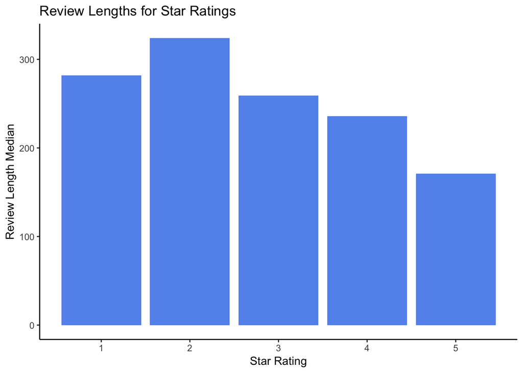

```r
Amazon_merge_reviews <- Amazon_merge %>% group_by(star_rating) %>% summarise(median_length = median(review_length, na.rm = TRUE))

ggplot(Amazon_merge_reviews, aes(star_rating, median_length)) +
  geom_col(fill = "cornflower blue") + theme_classic() + ggtitle("Review Lengths for Star Ratings") + labs(x = "Star Rating", y = "Review Length Median")
```

We decided to further look into the relationship between helpful votes and length of review over the different star ratings. We looked at how many helpful votes a review got based on its length for each of the star ratings, which we have facet wrapped.

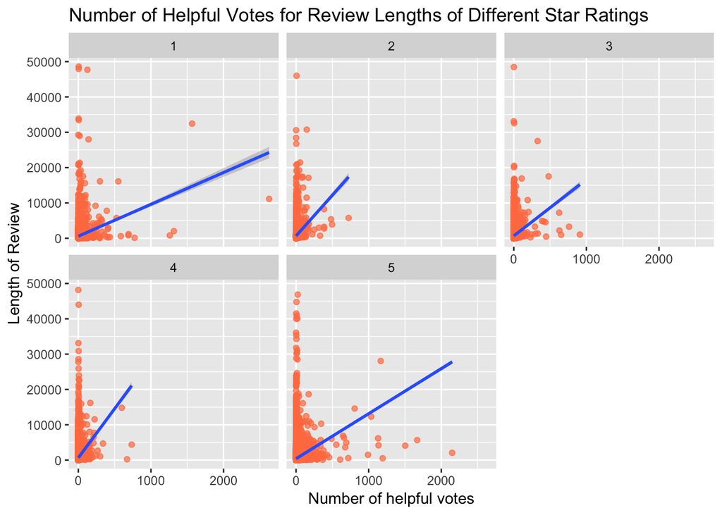

```r
ggplot(Amazon_merge, aes(helpful_votes, review_length)) +
  geom_point(alpha = 0.7, color = "coral") +
  facet_wrap(~factor(star_rating)) +
  geom_smooth(method = "lm") +
  ggtitle("Number of Helpful Votes for Review Lengths of Different Star Ratings") +
  labs(x = "Number of helpful votes", y = "Length of Review")
```

#### 3.

Our hypothesis is that longer reviews get more number of helpful votes irrespective of whether the purchasers are verified or not.  
In order to test this, we will look at:  
1. correlation between length of reviews and number of helpful votes  
- corr between helpful_votes and review_length  
2. summary statistics of helpful_votes to get basic information on the number of helpful votes like the minimum, maximum, mean, median, standard deviation and IQR  
3. t-test on review length and number of helpful votes  
- t-test(review_length, helpful_votes)  
4. t-test on number of helpful votes and verified purchase  
- t-test(verified_purchase, helpful_votes)  
5. regression analysis on number of helpful votes, verified purchases and length of review  
- lm(helpful_votes ~ review_length + verified purchase)

```r
cor(Amazon_merge$helpful_votes, Amazon_merge$review_length)
```

```
##      review_body
## [1,]   0.1593621
```

The correlation here shows us that the relationship between review length and number of helpful votes is not that strong as it is only 0.159.

```r
helpful_votes_summary <- Amazon_merge %>%
  summarise(min = min(helpful_votes),
            max = max(helpful_votes),
            mean = mean(helpful_votes),
            median = median(helpful_votes),
            sd = sd(helpful_votes),
            IQR = IQR(helpful_votes, na.rm = TRUE))
helpful_votes_summary
```

```
## # A tibble: 1 x 6
##     min   max  mean median    sd   IQR
##   <dbl> <dbl> <dbl>  <dbl> <dbl> <dbl>
## 1     0  2628  1.64      0  12.1     1
```

```r
review_length_summary <- Amazon_merge %>%
  summarise(min = min(review_length),
            max = max(review_length),
            mean = mean(review_length),
            median = median(review_length),
            sd = sd(review_length),
            IQR = IQR(review_length, na.rm = TRUE))
review_length_summary
```

```
## # A tibble: 1 x 6
##     min   max  mean median    sd   IQR
##   <int> <int> <dbl>  <int> <dbl> <dbl>
## 1     1 48604  493.    190 1011.   372
```

The summary of number of helpful votes and length of review gives us further insight into these variables.

```r
t.test(helpful_votes ~ review_length_groups, data = Amazon_merge, alternative = "less")
```

```
##
##  Welch Two Sample t-test
##
## data:  helpful_votes by review_length_groups
## t = -63.725, df = 241100, p-value < 2.2e-16
## alternative hypothesis: true difference in means is less than 0
## 95 percent confidence interval:
##       -Inf -2.242769
## sample estimates:
## mean in group Short Review  mean in group Long Review
##                  0.5011344                  2.8033276
```

Through the t-test we can see that shorter reviews do have lesser number of helpful votes as the p-value here is less than 0.05. The result is significant and null hypothesis is rejected. Our hypothesis suggested that short reviews had a lesser mean than long reviews.

```r
t.test(helpful_votes ~ verified_purchase, data = Amazon_merge)
```

```
##
##  Welch Two Sample t-test
##
## data:  helpful_votes by verified_purchase
## t = 29.936, df = 146330, p-value < 2.2e-16
## alternative hypothesis: true difference in means is not equal to 0
## 95 percent confidence interval:
##  1.504608 1.715429
## sample estimates:
## mean in group N mean in group Y
##        2.809206        1.199187
```

Through this t-test, we see that the p-value is less than 0.05 and null hypothesis is rejected. Thus, contrary to our hypothesis, this shows that there is a diiference between the non-verified group and verified group means.

```r
regression <- lm(formula = helpful_votes ~ review_length + verified_purchase, data = Amazon_merge)
summary(regression)
```

```
##
## Call:
## lm(formula = helpful_votes ~ review_length + verified_purchase,
##     data = Amazon_merge)
##
## Residuals:
##     Min      1Q  Median      3Q     Max
##  -91.15   -1.12   -0.83   -0.08 2606.21
##
## Coefficients:
##                      Estimate Std. Error t value Pr(>|t|)
## (Intercept)         8.563e-01  3.903e-02  21.938  < 2e-16 ***
## review_length       1.879e-03  1.865e-05 100.726  < 2e-16 ***
## verified_purchaseY -1.944e-01  4.220e-02  -4.606 4.12e-06 ***
## ---
## Signif. codes:  0 '***' 0.001 '**' 0.01 '*' 0.05 '.' 0.1 ' ' 1
##
## Residual standard error: 11.94 on 451340 degrees of freedom
## Multiple R-squared:  0.02544,    Adjusted R-squared:  0.02544
## F-statistic:  5891 on 2 and 451340 DF,  p-value: < 2.2e-16
```

The regression analysis further confirms our t-test. The p-value for length of review and verified purchase is smaller than 0.05 thus rejecting null hypothesis. This tells us that both, length of review and verification of purchaser, affect the number of helpful votes a review receives. Our hypothesis is therefore only partly true.